# Working with Web Tracking Data - Tutorial

### Sessions

A browsing session is a sequence of visits without a long gap in between. webtrackR’s `add_session()` assigns a session ID to each visit based on a timeout cutoff – if the gap between two consecutive visits exceeds the cutoff, a new session starts. A common choice is 30 minutes (1800 seconds):

```r
wtr_data <- add_session(wtr_data, cutoff = 1800)

cat("=== Sessions ===\n")
n_sessions <- wtr_data %>% distinct(panelist_id, session) %>% nrow()
cat("Total sessions across all panelists:", format(n_sessions, big.mark = ","), "\n")
```

```
## === Sessions ===
## Total sessions across all panelists: 44,408
```

```r
# Sessions per panelist
sessions_per_user <- wtr_data %>%
  group_by(panelist_id) %>%
  summarise(n_sessions = n_distinct(session), .groups = "drop")

cat("=== Sessions per Panelist ===\n")
cat("Mean:", round(mean(sessions_per_user$n_sessions), 1), "\n")
cat("Median:", median(sessions_per_user$n_sessions), "\n")
cat("Min:", min(sessions_per_user$n_sessions), "\n")
cat("Max:", format(max(sessions_per_user$n_sessions), big.mark = ","), "\n")
```

```
## === Sessions per Panelist ===
## Mean: 74
## Median: 47
## Min: 1
## Max: 462
```

```r
# Sessions per panelist per day
sessions_per_day <- wtr_data %>%
  mutate(date = as.Date(timestamp)) %>%
  group_by(panelist_id, date) %>%
  summarise(n_sessions = n_distinct(session), .groups = "drop")

cat("=== Sessions per Panelist per Day ===\n")
cat("Mean:", round(mean(sessions_per_day$n_sessions), 1), "\n")
cat("Median:", median(sessions_per_day$n_sessions), "\n")
cat("Max:", max(sessions_per_day$n_sessions), "\n")
```

```
## === Sessions per Panelist per Day ===
## Mean: 3.6
## Median: 3
## Max: 45
```

Note: The summary statistics don’t include days where no browsing sessions took place!

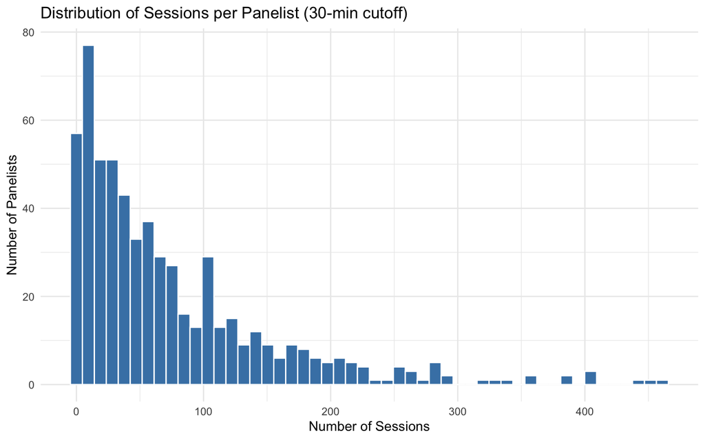

```r
ggplot(sessions_per_user, aes(x = n_sessions)) +
  geom_histogram(bins = 50, fill = "steelblue", color = "white") +
  labs(
    title = "Distribution of Sessions per Panelist (30-min cutoff)",
    x = "Number of Sessions",
    y = "Number of Panelists"
  ) +
  theme_minimal()
```

## Basic URL classification

Raw URLs are hard to analyze directly. To make sense of browsing behavior, we have to turn raw web-tracking URLs into variables we can analyze. There are two main strategies: **domain-based** classification (matching against known domains) and **path-based** classification (using URL path patterns like `/politik/` or `/search?q=`).

We’ll start with a simple **domain-based** classification using `case_when()` and regex patterns, then show how `webtrackR` streamlines this with `classify_visits()`.

```r
# Re-extract domain after deduplication (cleaning may drop extra columns)
wtr_data <- extract_domain(wtr_data, varname = "url")

# Manual classification using domain patterns
wtr_data <- wtr_data %>%
  mutate(
    category_regex = case_when(
      str_detect(domain, "spiegel|zeit\\.de|nachrichten|zeitung|tagesschau|sueddeutsche|faz\\.net|welt\\.de|t-online|heise") ~ "News",
      str_detect(domain, "wikipedia") ~ "Wikipedia",
      str_detect(domain, "amazon|ebay|kleinanzeigen|zalando|otto\\.de") ~ "E-commerce",
      str_detect(domain, "youtube|facebook|instagram|twitter|tiktok|reddit") ~ "Social/Video",
      str_detect(domain, "google|bing|duckduckgo|ecosia|yahoo") ~ "Search",
      is.na(domain) ~ "Other/Unclassified",
      TRUE ~ "Other/Unclassified"
    )
  )

cat("=== Classification Results (Manual) ===\n")
wtr_data %>%
  count(category_regex, sort = TRUE) %>%
  mutate(percentage = paste0(round(n / sum(n) * 100, 1), "%")) %>%
  print()
```

```
## === Classification Results (Manual) ===
##        category_regex      n percentage
##                <char>  <int>     <char>
## 1: Other/Unclassified 706977      72.3%
## 2:             Search 131594      13.5%
## 3:       Social/Video  59141       6.1%
## 4:         E-commerce  55821       5.7%
## 5:               News  12849       1.3%
## 6:          Wikipedia  10889       1.1%
```

This works, but manually writing regex for every domain is tedious and error-prone. The `classify_visits()` function from webtrackR offers a more structured approach. It takes a classification data frame that maps domains (or regex patterns) to categories:

```r
# Create a classification list as a data frame
# Each row maps a domain to a category
classification_df <- data.table::data.table(
  domain = c(
    # News
    "spiegel.de", "zeit.de", "tagesschau.de", "sueddeutsche.de",
    "faz.net", "welt.de", "t-online.de", "heise.de", "n-tv.de",
    # Social/Video
    "youtube.com", "facebook.com", "instagram.com", "twitter.com",
    "tiktok.com", "reddit.com",
    # E-commerce
    "amazon.de", "ebay.de", "kleinanzeigen.de", "zalando.de", "otto.de",
    # Search
    "google.com", "google.de", "bing.com", "duckduckgo.com", "ecosia.org",
    # Wikipedia
    "wikipedia.org"
  ),
  category_map = c(
    rep("News", 9),
    rep("Social/Video", 6),
    rep("E-commerce", 5),
    rep("Search", 5),
    "Wikipedia"
  )
)

# Apply classification using domain matching
wtr_data <- classify_visits(wtr_data, classes = classification_df, match_by = "domain")

cat("=== Classification Results (webtrackR) ===\n")
wtr_data %>%
  mutate(category_map = replace_na(category_map, "Other/Unclassified")) %>%
  count(category_map, sort = TRUE) %>%
  mutate(percentage = paste0(round(n / sum(n) * 100, 1), "%")) %>%
  print()
```

```
## === Classification Results (webtrackR) ===
##          category_map      n percentage
##                <char>  <int>     <char>
## 1: Other/Unclassified 711586      72.8%
## 2:             Search 128110      13.1%
## 3:       Social/Video  59141       6.1%
## 4:         E-commerce  54922       5.6%
## 5:               News  12657       1.3%
## 6:          Wikipedia  10855       1.1%
```

Note that `classify_visits()` with `match_by = "domain"` performs exact domain matching. Visits to domains not in our list get `NA`. This is more precise than regex but requires listing each domain explicitly. For a comprehensive classification, you would rely on a larger domain list.

### Check and improve the News classification

Our current News category may include misclassified domains. Because classification is a measurement decision, any errors at this stage directly affect all downstream analyses, such as visit counts, time measures, and correlations.

We considered two common approaches.

1. First, we classified domains using regex or pattern matching (e.g., domains containing “news”, “zeitung”, or “nachrichten”). This approach is flexible and useful for detecting previously unknown news sites. However, it carries a substantial risk of false positives and may miss important outlets that do not contain obvious keywords in their domain (e.g., brand-based domains “spiegel”).
2. Second, we can use domain-specific mapping based on curated news lists. This approach typically offers higher precision and is more transparent and reproducible. Its main limitation is that it depends on having a comprehensive and up-to-date list.

For substantive analysis, we therefore rely on existing curated domain lists such as webtrackR’s internal news type list and the [GOND-list](https://osf.io/s5uhb/overview). This provides a more methodologically defensible and reproducible classification. Regex-based methods remain useful for exploratory checks or for identifying unknown news domains to extend the list, but they should not serve as the primary classification strategy in a research setting.

```r
# First, inspect what is currently labeled as News (quick reality check)
wtr_data %>%
  filter(category_regex=='News') %>%
  distinct(domain)
```

```
##                            domain
##                            <char>
##  1:               sueddeutsche.de
##  2:                       welt.de
##  3:                      heise.de
##  4:                       zeit.de
##  5:                    spiegel.de
##  6:                 tagesschau.de
##  7:                       faz.net
##  8:                   t-online.de
##  9:                   netzwelt.de
## 10:            ruhrnachrichten.de
## 11:           location-zeitung.at
## 12:               kreiszeitung.de
## 13:               tagesspiegel.de
```

[output cut: 17 more lines]

If you see obviously non-news domains, it’s a sign that the regex-classification needs improvement. Looks like we mis-classified some domains. Let’s do the news classification using the GOND-list and WebtrackR’s internal news list.

```r
# load webtrackR's internal news-list
news_types <- webtrackR::news_types

# load GOND news list
gond <- read.csv(here::here("data", "GONDv3_domains.csv"), sep=',') %>%
  dplyr::filter(language=="de") %>%
  dplyr::select(domain)

# flag news based on domain-specific mapping
wtr_data <- wtr_data %>%
  mutate(is_news_gond = if_else(domain %in% gond$domain,1,0),
         is_news_webtrackR = if_else(domain %in% news_types$domain,1,0))


cat("=== Compare both news classifications ===\n")
table(wtr_data$is_news_gond, wtr_data$is_news_webtrackR)


cat("=== What is the share of news visits in the data? ===\n")
prop.table(table(wtr_data$is_news_gond))
```

```
## === Compare both news classifications ===
##
##          0      1
##   0 946094    923
##   1  13943  16311
## === What is the share of news visits in the data? ===
##
##          0          1
## 0.96904236 0.03095764
```

```r
cat("=== Most common news domains (first 20 rows) based on GOND-list ===\n")
wtr_data %>%
  filter(is_news_gond==1) %>%
  count(domain, sort = TRUE) %>%
  head(20)
```

```
## === Most common news domains (first 20 rows) based on GOND-list ===
##              domain     n
##              <char> <int>
##  1:     t-online.de  6976
##  2:       yahoo.com  3411
##  3:         bild.de  2933
##  4:          zdf.de  2175
##  5:   tagesschau.de  1822
##  6:        heise.de  1259
##  7:          hna.de   939
##  8:      spiegel.de   776
##  9: ardmediathek.de   743
## 10:         n-tv.de   696
## 11:          rtl.de   508
## 12:          ndr.de   412
## 13:      express.de   384
## 14:         zeit.de   384
## 15:         aol.com   370
## 16:     spektrum.de   341
## 17:          mdr.de   327
## 18:         welt.de   326
## 19:         faz.net   297
## 20:           br.de   264
##              domain     n
##              <char> <int>
```

```r
cat("=== Compare GOND news classification and category ===\n")
table(wtr_data$is_news_gond, wtr_data$category_regex)

wtr_data %>%
  dplyr::filter(is_news_gond==1) %>%
  dplyr::filter(category_regex=='Search') %>%
  distinct(domain)

# not in GOND-list, but flagged based on regex-news-classification
wtr_data %>%
  dplyr::filter(is_news_gond==0) %>%
  dplyr::filter(category_regex=='News') %>%
  distinct(domain)
```

```
## === Compare GOND news classification and category ===
##
##     E-commerce   News Other/Unclassified Search Social/Video Wikipedia
##   0      55821    575             692408 128183        59141     10889
##   1          0  12274              14569   3411            0         0
##       domain
##       <char>
## 1: yahoo.com
##                            domain
##                            <char>
##  1:                   netzwelt.de
##  2:           location-zeitung.at
##  3:           location-zeitung.de
##  4:       location-nachrichten.de
##  5:      abendzeitung-location.de
##  6:                     pcwelt.de
##  7:                   immowelt.de
##  8: deutsche-apotheker-zeitung.de
##  9:         ticket-onlineshop.com
## 10:                    macwelt.de
## 11:     bahnbonus-praemienwelt.de
## 12:                  kino-zeit.de
## 13:                   sparwelt.de
## 14:                  gameswelt.de
```

```r
# to keep it simple, we just overwrite our News category with the GOND-classification
wtr_data <- wtr_data %>%
  mutate(category_final = if_else(domain %in% gond$domain, 'News' , wtr_data$category_regex))
```

## Aggregation and summary statistics

Once visits are cleaned and classified, we usually want to aggregate the data to a meaningful unit of analysis that matches your research question. In panel studies, this is often the panelist level (e.g., total number of news visits per person).

We focus on the **Panelist-level** (each row = one person) → good for between-person differences (“who consumes more news?”). But there are also other options:

**Event-level** (each row = one visit) → good for sequences, timing, within-person dynamics.

**Panelist × category** (each row = person-category pair) → good for composition (“what share is politics vs sports?”).

Sometimes it is easier to aggregate by category and format the data to the wide format (one row per panelist, one column per category) afterwards.

```r
# Aggregate visits per panelist and category
panelist_summary <- wtr_data %>%
  group_by(panelist_id, category_final) %>%
  summarise(
    visits = n(),
    total_time = sum(duration, na.rm = TRUE),
    .groups = "drop"
  )

cat("=== Panelist-Level Summary (first 20 rows) ===\n")
panelist_summary %>%
  arrange(panelist_id) %>%
  head(20) %>%
  print()
```

```
## === Panelist-Level Summary (first 20 rows) ===
## # A tibble: 20 × 4
##    panelist_id category_final     visits total_time
##    <chr>       <chr>               <int>      <dbl>
##  1 0015885e    E-commerce              1       52.4
##  2 0015885e    News                    3       88.5
##  3 0015885e    Other/Unclassified    138     3129.
##  4 0015885e    Search                170     1551.
##  5 0015885e    Social/Video           22      224.
##  6 0015885e    Wikipedia               6      118.
##  7 00ce9cb3    E-commerce             25     1034.
##  8 00ce9cb3    News                   28     1499.
##  9 00ce9cb3    Other/Unclassified   2813    89107.
## 10 00ce9cb3    Search                208     5808.
## 11 00ce9cb3    Social/Video           37     1882.
## 12 00ed00d9    E-commerce             10      124.
## 13 00ed00d9    Other/Unclassified    353     4175.
## 14 00ed00d9    Search                131     1814.
## 15 00ed00d9    Social/Video           21     1044.
## 16 017b5864    News                   85     1479.
## 17 017b5864    Other/Unclassified    582    15161.
## 18 017b5864    Search                165     3092.
## 19 017b5864    Social/Video            1        0
## 20 017b5864    Wikipedia               5      400.
```

Now let’s transform the data to a wide-format.

```r
panelist_summary_wide <- panelist_summary %>%
  dplyr::select(panelist_id, category_final, visits) %>%
  tidyr::pivot_wider(
    names_from = category_final,
    values_from = visits,
    values_fill = 0,
    names_glue  = "{category_final}_visits"
  )

cat("=== Wide Format (first 10 rows) ===\n")
head(panelist_summary_wide, 10)
```

```
## === Wide Format (first 10 rows) ===
## # A tibble: 10 × 7
##    panelist_id `E-commerce_visits` News_visits `Other/Unclassified_visits`
##    <chr>                     <int>       <int>                       <int>
##  1 0015885e                      1           3                         138
##  2 00ce9cb3                     25          28                        2813
##  3 00ed00d9                     10           0                         353
##  4 017b5864                      0          85                         582
##  5 01f1dc6e                     66           7                         749
##  6 0262123a                     64           3                         374
##  7 02f86623                     61          24                        1299
##  8 033054f7                     68          55                         871
##  9 03d18cef                     45          33                        1867
## 10 03f318a6                      0           6                         141
## # ℹ 3 more variables: Search_visits <int>, `Social/Video_visits` <int>,
## #   Wikipedia_visits <int>
```

Something is still missing. We should also include the total number of visits per person. This variable serves as a baseline measure of overall online activity. Without accounting for it, we risk mistaking general internet use for the effect of our variable of interest. For example, people with higher political interest might simply browse more overall — not necessarily allocate more of their browsing to news.

```r
df_ind <- wtr_data %>%
  group_by(panelist_id) %>%
  summarise(
    n_visits = n(),
    total_time = sum(duration, na.rm = TRUE),
    total_news_time = sum(duration[is_news_gond == 1], na.rm = TRUE),
    .groups = "drop"
  )

# join the data
df_ind <- df_ind %>%
  left_join(panelist_summary_wide)
```

## Linking survey data

A key advantage of panel web tracking studies such as the GESIS panel (Campusfile: ZA5670) is that browsing data can be linked to survey responses.

For demonstration purposes, we merge the corresponding survey file that contains panelist-level variables such as age, gender, education and political interest.

```r
# Example: Load survey data (synthetic demo file)
survey_data <- read.csv2(here::here("data", "ZA5670_survey_data.csv"))

cat("=== Survey Data Structure ===\n")
glimpse(survey_data)

# select basic demographics
survey_data <- survey_data %>%
  dplyr::select(panelist_id, da119a_sex, da120a_ybrth, da127a_seduc, ca110a_polin) %>%
  mutate(
    # Gender → binary 0/1
    da119a_sex = case_when(
      da119a_sex == "male"   ~ 1,
      da119a_sex == "female" ~ 0,
      TRUE ~ NA_real_
    ),

    # Age groups
    da120a_ybrth = factor(
      da120a_ybrth,
      levels = c("18-29", "30-44", "45-59", "60+"),
    ),
    da120a_ybrth_num = as.numeric(da120a_ybrth),

    # Education
    da127a_seduc = factor(
      da127a_seduc,
      levels = c("low", "medium", "high"),
    ),
    da127a_seduc_num = as.numeric(da127a_seduc),

    political_interest = factor(
      ca110a_polin,
      levels = c(5, 4, 3, 2, 1),
      labels = c("Very Low", "Low", "Medium", "High", "Very High"),
    ),
    political_interest_num = as.numeric(political_interest)
  )


# Merge aggregated web tracking data with survey responses
analysis_data <- df_ind %>%
  left_join(survey_data, by = "panelist_id")

cat("\n=== Merged Dataset (first 10 rows) ===\n")
head(analysis_data, 10)
```

```
## === Survey Data Structure ===
## Rows: 600
## Columns: 65
## $ panelist_id  <chr> "7e34a03c", "3937357f", "a0e12772", "5debbc5c", "5029d410…
## $ da119a_sex   <chr> "female", "male", "male", "male", "male", "female", "male…
## $ da120a_ybrth <chr> "45-59", "45-59", "60+", "30-44", "60+", "18-29", "30-44"…
## $ da127a_seduc <chr> "medium", "medium", "high", "high", "medium", "medium", "…
## $ da146a_empsi <chr> "not employed", "employed", "not employed", "employed", "…
## $ da149a_hhsiz <chr> "2+ persons", "2+ persons", "2+ persons", "1-person", "1-…
## $ da124a_mstat <chr> "married", "married", "married", "not married", "not marr…
## $ ca110a_polin <int> 2, 1, 1, 1, 3, 3, 2, 1, 1, 2, 1, 2, 4, 2, 3, 1, 3, 1, 3, …
## $ ca113a_pollr <int> 6, 2, 3, 1, 6, 6, 4, 8, 8, 2, 11, 1, 7, 7, 3, 8, 6, 3, 6,…
## $ ca114a_satde <int> 1, 3, 2, 1, 4, 3, 4, 2, 2, 4, 4, 4, 2, 3, 1, 1, 2, 4, 4, …
## $ lc92_1       <int> 2, 1, 2, 1, 3, 3, 3, 1, 1, 3, 1, 2, 3, 2, 2, NA, 1, 2, 3,…
## $ lc93_1       <int> 5, 4, 4, 5, 3, 3, 2, 5, 5, 5, 5, 4, 1, 3, 3, NA, 4, 4, 3,…
```

[output cut: 73 more lines]

Now we can examine relationships between browsing behavior and survey variables.

For example: Is political interest associated with more visits to news websites?

```r
# correlation matrix
analysis_data %>%
  select(n_visits, News_visits, contains('num')) %>%
  cor(method = "spearman", use = "pairwise.complete.obs")
```

```
##                           n_visits News_visits da120a_ybrth_num
## n_visits               1.000000000  0.60196085       0.03847654
## News_visits            0.601960847  1.00000000       0.16976483
## da120a_ybrth_num       0.038476536  0.16976483       1.00000000
## da127a_seduc_num       0.003315578  0.06746839      -0.24851524
## political_interest_num 0.109677902  0.13165966       0.18256245
##                        da127a_seduc_num political_interest_num
## n_visits                    0.003315578             0.10967790
## News_visits                 0.067468391             0.13165966
## da120a_ybrth_num           -0.248515244             0.18256245
## da127a_seduc_num            1.000000000             0.09071065
## political_interest_num      0.090710649             1.00000000
```

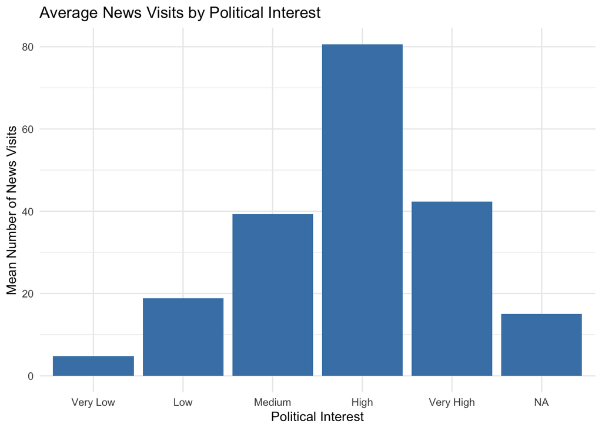

```r
analysis_data %>%
  group_by(political_interest) %>%
  summarise(mean_news_visits = mean(News_visits, na.rm = TRUE)) %>%
  ggplot(aes(x = political_interest, y = mean_news_visits)) +
  geom_col(fill = "steelblue") +
  labs(
    title = "Average News Visits by Political Interest",
    x = "Political Interest",
    y = "Mean Number of News Visits"
  ) +
  theme_minimal()
```

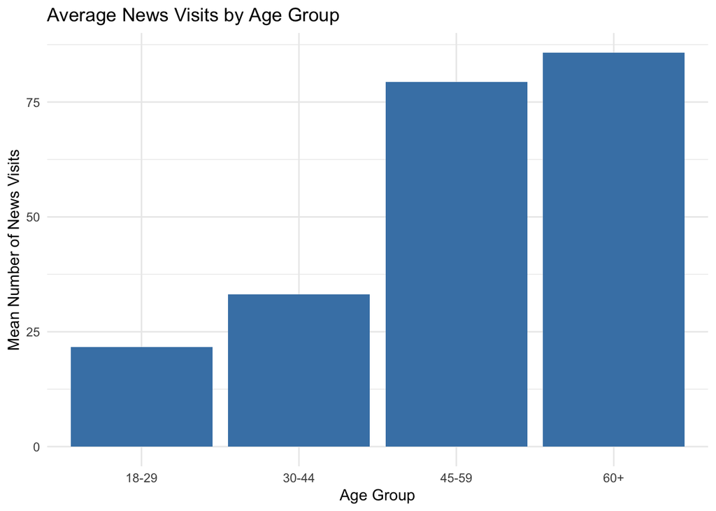

```r
analysis_data %>%
  group_by(da120a_ybrth) %>%
  summarise(mean_news_visits = mean(News_visits, na.rm = TRUE)) %>%
  ggplot(aes(x = da120a_ybrth, y = mean_news_visits)) +
  geom_col(fill = "steelblue") +
  labs(
    title = "Average News Visits by Age Group",
    x = "Age Group",
    y = "Mean Number of News Visits"
  ) +
  theme_minimal()
```

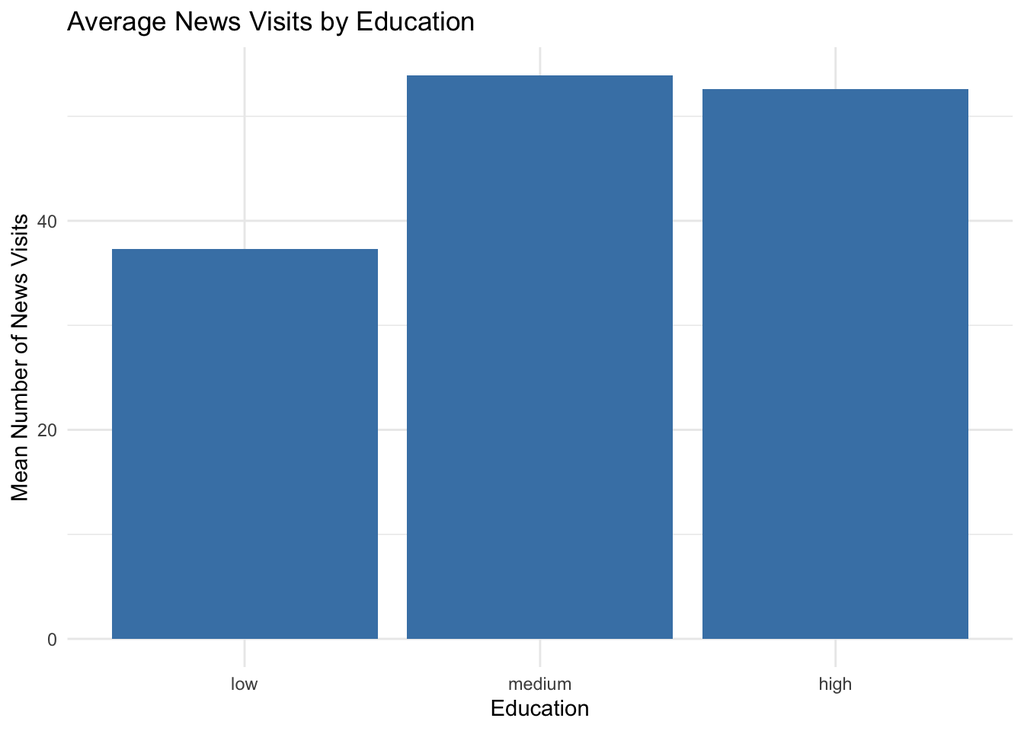

```r
analysis_data %>%
  filter(!is.na(da127a_seduc)) %>%
  group_by(da127a_seduc) %>%
  summarise(mean_news_visits = mean(News_visits, na.rm = TRUE)) %>%
  ggplot(aes(x = da127a_seduc, y = mean_news_visits)) +
  geom_col(fill = "steelblue") +
  labs(
    title = "Average News Visits by Education",
    x = "Education",
    y = "Mean Number of News Visits"
  ) +
  theme_minimal()
```

## Wrap-up and next steps

In this tutorial, we walked through the essential preprocessing steps for web tracking data:

- Loading and inspecting raw tracking data
- Parsing and extracting URL components
- Cleaning artifacts and deduplicating visits
- Classifying visits into meaningful categories
- Aggregating browsing behavior at the panelist level
- Linking behavioral data with survey responses

What comes next? Depending on your research question, you might:

- Detect sessions and browsing sequences
- Study media diets and exposure diversity
- Analyze temporal dynamics (e.g., reactions to events)
- Model behavioral outcomes using regression or multilevel models

**Reminder: Always run sanity checks after data cleaning, merging, and transformation steps to verify that everything worked as expected.**

# Outlook: Modeling

We can also estimate models using the `glmmTMB` package. Because our outcome is a count variable (number of visits), we use a negative binomial (nbinom2) model. Web-tracking counts are typically highly skewed and show large differences between individuals, so standard linear models are not appropriate — they assume normally distributed errors and can produce unrealistic predictions.

The negative binomial model is well suited for this type of overdispersed count data. In addition, `glmmTMB` is flexible and allows us to extend the model to a multilevel framework if we later include repeated measurements.

```r
if(!('glmmTMB' %in% installed.packages()[,"Package"])){

  install.packages('glmmTMB')
}
```

```r
library(glmmTMB)

model <- glmmTMB::glmmTMB(
  News_visits ~
    political_interest_num +
    da119a_sex + da120a_ybrth + da127a_seduc +
    n_visits,
  family = nbinom2,
  data = analysis_data %>%
    drop_na(political_interest_num, da127a_seduc)
)

summary(model)

# missings
analysis_data %>%
  summarise(across(c(News_visits, political_interest_num, da119a_sex, da120a_ybrth, da127a_seduc), ~ sum(is.na(.))))
```

[output not shown]

# Exercises

Try these exercises on your own to practice what you’ve learned:

## 1. Custom classification

Create a classification scheme for German news outlets (Spiegel vs Zeit vs Tagesschau, etc.)

```r
# Hint: Use classify_visits() with a more granular classification data frame
# where each news domain maps to its own category instead of all being "News"
# classification_news <- data.table::data.table(
#   domain = c("spiegel.de", "zeit.de", "tagesschau.de", ...),
#   outlet = c("Spiegel", "Zeit", "Tagesschau", ...)
# )
# wtr_data <- classify_visits(wtr_data, classes = classification_news, match_by = "domain")
```

## 2. Temporal analysis

Calculate average visit duration by hour of day. When are people browsing most actively?

```r
# Hint: Extract hour from timestamp, group by hour, summarise duration
```

## 3. User segmentation

Identify different browsing profiles (news readers, shoppers, video watchers, etc.) based on category proportions.

```r
# Hint: Calculate share of visits per category per panelist
# Then identify the dominant category per panelist with which.max()
```

## 4. Path analysis

For YouTube videos, extract the video ID from URLs and identify most-watched videos.

```r
# Hint: Use ada_get_search() from adaR to extract query string,
# (note: youtube has many URL formats, if you want to be extra thorough,
# you can also inspect the paths of youtube URLs, see https://gist.github.com/rodrigoborgesdeoliveira/987683cfbfcc8d800192da1e73adc486 for examples)
```

## 5. Survey correlation

Test if browsing behavior (total visits, category preferences) correlates with demographic variables from survey data.

```r
# Hint: First aggregate visits per panelist, then join with survey data,
# then compare groups (e.g., boxplot of news visits by education level)
```

## 6. Sub-divide paths

Can you subdivide news visits into subcategories (politics, sports, culture) using the `path` column?

```r
# Hint: use `str_detect(path, "politik|politics")` patterns on the path component.
```

# Further resources

- [webtrackR documentation](https://github.com/schochastics/webtrackR)
- [adaR documentation](https://github.com/gesistsa/adaR)
- [“Analysis of Web Browsing Data” Practical guide](https://bernhardclemm.com/browsing-data-code-guide/guide.html#defining-visit-duration)
- [Clemm et al. “Analysis of Web Browsing Data: A Guide”] (https://journals.sagepub.com/doi/10.1177/08944393241227868)
- [GESIS Guides to Digital Behavioral Data #23: Overview of Working with Web Tracking Data](https://doi.org/10.60762/ggdbd25023.1.0)

# Reproducibility Information

This tutorial was developed and tested with the following system and package versions:

```
## Notebook built on: 2026-02-24
##
## System Information:
##   R version: 4.3.1
##   Platform: aarch64-apple-darwin20
##   OS: darwin20
##
## Package Versions:
##   here: v1.0.1
##   adaR: v0.3.4
##   webtrackR: v0.3.1
##   lubridate: v1.9.4
##   forcats: v1.0.0
##   stringr: v1.5.1
##   dplyr: v1.1.4
##   purrr: v1.0.4
##   readr: v2.1.5
##   tidyr: v1.3.1
##   tibble: v3.3.0
##   ggplot2: v3.5.2
##   tidyverse: v2.0.0
```

**Minimum Requirements:**

- R version: >= 4.0.0
- Required packages: tidyverse, webtrackR, adaR, here